# Analysing clinical data of patients diagnosed with brain cancer - lab report 2

430189999

5/4/2019

```r
###REARRANGE COLS
##arrange df vars by position
##'vars' must be a named vector, e.g. c("var.name"=1)
arrange.vars <- function(data, vars){
    ##stop if not a data.frame (but should work for matrices as well)
    stopifnot(is.data.frame(data))

    ##sort out inputs
    data.nms <- names(data)
    var.nr <- length(data.nms)
    var.nms <- names(vars)
    var.pos <- vars
    ##sanity checks
    stopifnot( !any(duplicated(var.nms)),
               !any(duplicated(var.pos)) )
    stopifnot( is.character(var.nms),
               is.numeric(var.pos) )
    stopifnot( all(var.nms %in% data.nms) )
    stopifnot( all(var.pos > 0),
               all(var.pos <= var.nr) )

    ##prepare output
    out.vec <- character(var.nr)
    out.vec[var.pos] <- var.nms
    out.vec[-var.pos] <- data.nms[ !(data.nms %in% var.nms) ]
    stopifnot( length(out.vec)==var.nr )

    ##re-arrange vars by position
    data <- data[ , out.vec]
    return(data)
}

#USAGE
#table <- data.frame(Time=c(1,2), In=c(2,3), Out=c(3,4), Files=c(4,5))
#table
##  Time In Out Files
##1    1  2   3     4
##2    2  3   4     5

#arrange.vars(table, c("Out"=2))
##  Time Out In Files
##1    1   3  2     4
##2    2   4  3     5

#arrange.vars(table, c("Out"=2, "Files"=1, "Time"=4))
##  Files Out In Time
##1     4   3  2    1
##2     5   4  3    2
```

### Note: I’ve used the same data and cleaning process from my first lab report so some parts might be repeated.

### What is brain cancer?

https://www.cancer.org.au/about-cancer/types-of-cancer/brain-cancer.html: from Cancer Council Australa:

Brain cancers include primary brain tumours, which start in the brain and almost never spread to other parts of the body, and secondary tumours (or metastases), which are caused by cancers that began in another part of the body.

```r
##loading data
library(readxl)
require(dplyr)
require(tibble)
require(ggplot2)
require(stringr)
explore <- read_excel("~/Uni/Uni - Sem 1 - 2019/AMED3002/clinical_2014-01-16.xlsx")
colnames(explore)
glimpse(explore)
#removing columns that are almost entirely empty
masterDF<- explore[,-c(15:27)]
masterDF <- masterDF[,-c(10)]
```

## Data

The data was a sample of this data set: “https://www.ncbi.nlm.nih.gov/geo/download/?acc=GSE108474&format=file&file=GSE108474%5FREMBRANDT%5Fdata%2Edictionary%2Exlsx” The data was collected at the George Town Lombardi Comprehensive Cancer Centre, Washington DC, USA. It contains anonymized clinical data, including pesonal details of patients, diagnosis, survival time, treatments and surgeries.

Details of observations and variables:

```r
#dimensions of data
glimpse(masterDF)
```

```
## Observations: 127
## Variables: 22
## $ Sample                                    <chr> "900_00_1961", "900_00…
## $ `Age at Dx (years)`                       <chr> "--", "--", "--", "--"…
## $ Gender                                    <chr> "--", "--", "--", "--"…
## $ `Survival (months)`                       <chr> "15", "15", "17", "17"…
## $ Disease                                   <chr> "ASTROCYTOMA", "GBM", …
## $ Grade                                     <chr> "II", "--", "III", "--…
## $ Race                                      <chr> "--", "--", "--", "--"…
## $ Institution                               <chr> "TJU", "TJU", "TJU", "…
## $ Karnofsky                                 <chr> "--", "--", "--", "--"…
## $ `MRI Desc`                                <chr> "--", "--", "--", "--"…
## $ `Followup Month`                          <chr> "--", "--", "--", "--"…
## $ `Steroid Dose Status`                     <chr> "--", "--", "--", "--"…
## $ `Anti-Convulsant Status`                  <chr> "--", "--", "--", "--"…
## $ `OnStudy Therapy Radiation Type`          <chr> "--", "--", "--", "--"…
## $ `OnStudy Therapy Chemo Agent Name`        <chr> "--", "--", "--", "--"…
## $ `OnStudy Therapy Chemo Course Count`      <chr> "--", "--", "--", "--"…
## $ `OnStudy Therapy Surgery Procedure Title` <chr> "--", "--", "--", "--"…
## $ `OnStudy Therapy Surgery Indication`      <chr> "--", "--", "--", "--"…
## $ `OnStudy Therapy Surgery Histo Diagnosis` <chr> "--", "--", "--", "--"…
## $ `OnStudy Therapy Surgery Outcome`         <chr> "--", "--", "--", "--"…
## $ ...35                                     <chr> NA, NA, NA, NA, NA, NA…
## $ ...36                                     <chr> NA, NA, NA, NA, NA, NA…
```

### Cleaning

The data was entirely in a character format, so columns were converted to their appropriate types. Survival Time was particulary bad with values like “109.9999999999” and some large outliers.

The age data was given in ranges like “14-19”, “34-39” which made it hard to analyse. The null values were removed, and the strings treated as catgeorical variables.

```r
df <- masterDF
df$`Survival (months)` <- as.numeric(as.character(df$`Survival (months)`))
df$`Survival (months)` <- trunc(df$`Survival (months)`)
df %>% filter(!is.na(Disease), !is.na(`Survival (months)`), !is.na(df$Gender))
df <- filter(df,df$`Survival (months)` < 200)

df <- subset(df, df$Disease != "--")
df <- subset(df, df$Gender != "--")
df <- subset(df, df$Gender != "-")
df <- subset(df, df$Race != "--")
df <- subset(df, df$`Age at Dx (years)` != "--")
```

A lot of the data involving the clinical records of treatment was messy and unstandardized, the easiest method cleaning and retaining the information was to convert it into a boolean form.

```r
df$`Steroid Dose Status`[df$`Steroid Dose Status`=="NASS"] <- "NO"
df$`Steroid Dose Status`[df$`Steroid Dose Status`=="--"] <- "NO"
df$`Steroid Dose Status`[df$`Steroid Dose Status`=="NONE"] <- "NO"
df$`Steroid Dose Status`[df$`Steroid Dose Status`!="NO"] <- "YES"

df$`Anti-Convulsant Status`[df$`Anti-Convulsant Status`=="NASS"] <- "NO"
df$`Anti-Convulsant Status`[df$`Anti-Convulsant Status`=="--"] <- "NO"
df$`Anti-Convulsant Status`[df$`Anti-Convulsant Status`=="NONE"] <- "NO"
df$`Anti-Convulsant Status`[df$`Anti-Convulsant Status`!="NO"] <- "YES"

df$`OnStudy Therapy Radiation Type`[df$`OnStudy Therapy Radiation Type`=="NASS"] <- "NO"
df$`OnStudy Therapy Radiation Type`[df$`OnStudy Therapy Radiation Type`=="NONE"] <- "NO"
df$`OnStudy Therapy Radiation Type`[df$`OnStudy Therapy Radiation Type`=="--"] <- "NO"
df$`OnStudy Therapy Radiation Type`[df$`OnStudy Therapy Radiation Type`=="No"] <- "NO"
df$`OnStudy Therapy Radiation Type`[df$`OnStudy Therapy Radiation Type`!="NO"] <- "YES"

df$`OnStudy Therapy Chemo Agent Name`
df$`OnStudy Therapy Chemo Agent Name`[df$`OnStudy Therapy Chemo Agent Name`=="NASS"] <- "NO"
df$`OnStudy Therapy Chemo Agent Name`[df$`OnStudy Therapy Chemo Agent Name`=="--"] <- "NO"
df$`OnStudy Therapy Chemo Agent Name`[df$`OnStudy Therapy Chemo Agent Name`=="NONE(NONE)"] <- "NO"
df$`OnStudy Therapy Chemo Agent Name`[df$`OnStudy Therapy Chemo Agent Name`=="No(No)"] <- "NO"
df$`OnStudy Therapy Chemo Agent Name`[df$`OnStudy Therapy Chemo Agent Name`=="NO(NO)"] <- "NO"
df$`OnStudy Therapy Chemo Agent Name`[df$`OnStudy Therapy Chemo Agent Name`!="NO"] <- "YES"

df.extended <- mutate(df, four.years = ifelse(`Survival (months)` >= 48, "YES","NO"))
```

## Analysis

**Does gender have an effect on surviving more than four years?** We can perform a chi squared test of proportions

```r
library(questionr)
tbl <- table(df.extended$Gender, df.extended$four.years)
odds.ratio(tbl)
```

```
##                    OR   2.5 % 97.5 %      p
## Fisher's test 1.17144 0.42739 3.2452 0.8174
```

```r
chisq.test(tbl)
```

```
##
##  Pearson's Chi-squared test with Yates' continuity correction
##
## data:  tbl
## X-squared = 0.012187, df = 1, p-value = 0.9121
```

```r
fisher.test(tbl)
```

```
##
##  Fisher's Exact Test for Count Data
##
## data:  tbl
## p-value = 0.8174
## alternative hypothesis: true odds ratio is not equal to 1
## 95 percent confidence interval:
##  0.4273924 3.2452157
## sample estimates:
## odds ratio
##   1.171436
```

Conclusion: The p-value of 0.91 and 0.81 with one degree of freedom suggests that gender is not a factor in surviving more than four years, as the differences in counts can very likely be attributed to differences in sample size.

We can perform dimension reduction to get an idea of how the variance in the data is distributed.

We first need to perform data munging the data to do pca.

```r
#drop

glimpse(df)
```

```
## Observations: 76
## Variables: 22
## $ Sample                                    <chr> "HF0608", "HF0835", "H…
## $ `Age at Dx (years)`                       <chr> "50-54", "35-39", "55-…
## $ Gender                                    <chr> "M", "F", "M", "M", "F…
## $ `Survival (months)`                       <dbl> 10, 45, 13, 66, 1, 119…
## $ Disease                                   <chr> "ASTROCYTOMA", "OLIGOD…
## $ Grade                                     <chr> "II", "II", "II", "II"…
## $ Race                                      <chr> "WHITE", "WHITE", "WHI…
## $ Institution                               <chr> "HENRY FORD HOSPITAL (…
## $ Karnofsky                                 <chr> "--", "90", "90", "--"…
## $ `MRI Desc`                                <chr> "rim enhancement and n…
## $ `Followup Month`                          <chr> "--", "--", "irregular…
## $ `Steroid Dose Status`                     <chr> "NO", "NO", "NO", "NO"…
## $ `Anti-Convulsant Status`                  <chr> "NO", "YES", "NO", "NO…
## $ `OnStudy Therapy Radiation Type`          <chr> "YES", "YES", "NO", "Y…
## $ `OnStudy Therapy Chemo Agent Name`        <chr> "YES", "YES", "YES", "…
## $ `OnStudy Therapy Chemo Course Count`      <chr> "--", "--", "BCNU(4)",…
## $ `OnStudy Therapy Surgery Procedure Title` <chr> "subtotal x2", "subtot…
## $ `OnStudy Therapy Surgery Indication`      <chr> "recurrence", "recurre…
## $ `OnStudy Therapy Surgery Histo Diagnosis` <chr> "GBM with necrosis", "…
## $ `OnStudy Therapy Surgery Outcome`         <chr> "subtotal", "subtotal"…
## $ ...35                                     <chr> NA, NA, "subtotal", NA…
## $ ...36                                     <chr> NA, NA, NA, NA, NA, NA…
```

```r
colnames(df)
```

```
##  [1] "Sample"
##  [2] "Age at Dx (years)"
##  [3] "Gender"
##  [4] "Survival (months)"
##  [5] "Disease"
##  [6] "Grade"
##  [7] "Race"
##  [8] "Institution"
##  [9] "Karnofsky"
## [10] "MRI Desc"
## [11] "Followup Month"
## [12] "Steroid Dose Status"
## [13] "Anti-Convulsant Status"
## [14] "OnStudy Therapy Radiation Type"
## [15] "OnStudy Therapy Chemo Agent Name"
## [16] "OnStudy Therapy Chemo Course Count"
## [17] "OnStudy Therapy Surgery Procedure Title"
## [18] "OnStudy Therapy Surgery Indication"
## [19] "OnStudy Therapy Surgery Histo Diagnosis"
## [20] "OnStudy Therapy Surgery Outcome"
## [21] "...35"
## [22] "...36"
```

```r
df.pca <- df[-c(1)]
df.pca <- df.pca[-c(20:21)]
arrange.vars(df.pca, c("Survival (months)"=2))
```

```
## # A tibble: 76 x 19
##    `Age at Dx (yea… `Survival (mont… Gender Disease Grade Race  Institution
##    <chr>                       <dbl> <chr>  <chr>   <chr> <chr> <chr>
##  1 50-54                          10 M      ASTROC… II    WHITE HENRY FORD…
##  2 35-39                          45 F      OLIGOD… II    WHITE HENRY FORD…
##  3 55-59                          13 M      ASTROC… II    WHITE HENRY FORD…
##  4 55-59                          66 M      ASTROC… II    WHITE HENRY FORD…
##  5 85-89                           1 F      OLIGOD… II    WHITE HENRY FORD…
##  6 35-39                         119 F      ASTROC… II    WHITE HENRY FORD…
##  7 35-39                          44 M      ASTROC… II    WHITE HENRY FORD…
##  8 30-34                          88 F      OLIGOD… II    WHITE HENRY FORD…
##  9 30-34                         116 M      OLIGOD… II    WHITE HENRY FORD…
## 10 50-54                         137 M      ASTROC… III   WHITE HENRY FORD…
## # … with 66 more rows, and 12 more variables: Karnofsky <chr>, `MRI
## #   Desc` <chr>, `Followup Month` <chr>, `Steroid Dose Status` <chr>,
## #   `Anti-Convulsant Status` <chr>, `OnStudy Therapy Radiation
## #   Type` <chr>, `OnStudy Therapy Chemo Agent Name` <chr>, `OnStudy
## #   Therapy Chemo Course Count` <chr>, `OnStudy Therapy Surgery Procedure
## #   Title` <chr>, `OnStudy Therapy Surgery Indication` <chr>, `OnStudy
## #   Therapy Surgery Histo Diagnosis` <chr>, `OnStudy Therapy Surgery
## #   Outcome` <chr>
```

```r
df.pca <- rename(df.pca,c('Steroid Dose Status' = 'hadSteroids'))
df.pca <- rename(df.pca,c('Anti-Convulsant Status' = 'hadAntiConvulsant'))
df.pca <- rename(df.pca,c('OnStudy Therapy Radiation Type' = 'hadRadio'))
df.pca <- rename(df.pca,c('OnStudy Therapy Chemo Agent Name' = 'hadChemo'))
df.pca <- rename(df.pca,c('Age at Dx (years)' = 'ageRange'))
df.pca <- rename(df.pca,c('Survival (months)' = 'monthsSurvived'))

df.pca <- df.pca %>%  select(Gender, monthsSurvived, ageRange, Disease, hadSteroids, hadAntiConvulsant, hadRadio, hadChemo)

character_vars <- lapply(df.pca, class) == "character"
df.pca[, character_vars] <- lapply(df.pca[, character_vars], as.factor)

df.pca <- na.omit(df.pca)
```

```r
library(ggdendro)
library(ape)

dataContinuous = as.data.frame(model.matrix(~.,df.pca)[,-1])
df3 <- dataContinuous

df3 <- df3 %>% filter(df3$monthsSurvived > 0)
pca = prcomp(df3, scale = TRUE)

summary(pca)$importance[,1:6]
```

```
##                             PC1      PC2      PC3      PC4      PC5
## Standard deviation     1.556359 1.368964 1.339761 1.215825 1.163032
## Proportion of Variance 0.105320 0.081480 0.078040 0.064270 0.058810
## Cumulative Proportion  0.105320 0.186800 0.264840 0.329110 0.387920
##                             PC6
## Standard deviation     1.120452
## Proportion of Variance 0.054580
## Cumulative Proportion  0.442500
```

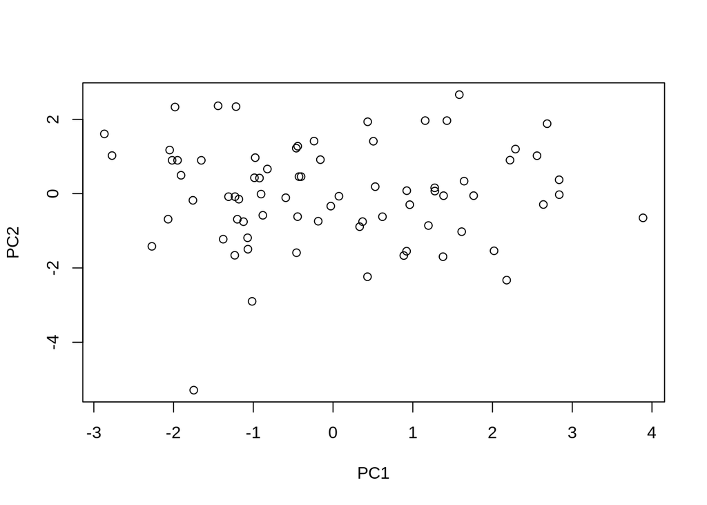

```r
plot(pca$x[,1:2])
```

```r
rownames(pca$rotation)
```

```
##  [1] "GenderM"                  "monthsSurvived"
##  [3] "ageRange15-19"            "ageRange20-24"
##  [5] "ageRange25-29"            "ageRange30-34"
##  [7] "ageRange35-39"            "ageRange40-44"
##  [9] "ageRange45-49"            "ageRange50-54"
## [11] "ageRange55-59"            "ageRange60-64"
## [13] "ageRange65-69"            "ageRange70-74"
## [15] "ageRange75-79"            "ageRange85-89"
## [17] "DiseaseGBM"               "DiseaseMIXED"
## [19] "DiseaseOLIGODENDROGLIOMA" "hadSteroidsYES"
## [21] "hadAntiConvulsantYES"     "hadRadioYES"
## [23] "hadChemoYES"
```

```r
sort(pca$rotation[,1])
```

```
##               DiseaseGBM              hadRadioYES              hadChemoYES
##              -0.42152186              -0.36700981              -0.26064211
##            ageRange70-74            ageRange65-69            ageRange40-44
##              -0.16691156              -0.14928582              -0.13652153
##            ageRange75-79            ageRange60-64             DiseaseMIXED
##              -0.11454306              -0.09438131              -0.08499097
##            ageRange55-59            ageRange50-54            ageRange45-49
##              -0.06558473              -0.06147032              -0.02288690
##                  GenderM            ageRange15-19            ageRange25-29
##              -0.01055080               0.07589141               0.09934864
##            ageRange35-39            ageRange20-24            ageRange30-34
##               0.12413424               0.14973955               0.16830390
##           hadSteroidsYES            ageRange85-89 DiseaseOLIGODENDROGLIOMA
##               0.16929332               0.18913722               0.32558711
##           monthsSurvived     hadAntiConvulsantYES
##               0.33437738               0.38587957
```

```r
sort(pca$rotation[,2])
```

```
##           hadSteroidsYES              hadChemoYES             DiseaseMIXED
##            -0.4214357076            -0.3736211616            -0.3325708582
##            ageRange60-64              hadRadioYES     hadAntiConvulsantYES
##            -0.3193314672            -0.3060456936            -0.2703970023
##            ageRange50-54            ageRange30-34 DiseaseOLIGODENDROGLIOMA
##            -0.1833899184            -0.1531762463            -0.0411969831
##            ageRange85-89            ageRange40-44           monthsSurvived
##            -0.0409806813            -0.0069765353            -0.0005551355
##            ageRange35-39            ageRange15-19               DiseaseGBM
##             0.0025540491             0.0253324475             0.0304376625
##            ageRange55-59            ageRange25-29            ageRange70-74
##             0.0385139483             0.0920201789             0.1151276975
##            ageRange45-49            ageRange20-24            ageRange65-69
##             0.1184078424             0.1402100900             0.1778230876
##            ageRange75-79                  GenderM
##             0.1964123135             0.3380325826
```

```r
cor(df3$DiseaseGBM, df3$monthsSurvived)
```

```
## [1] -0.3069045
```

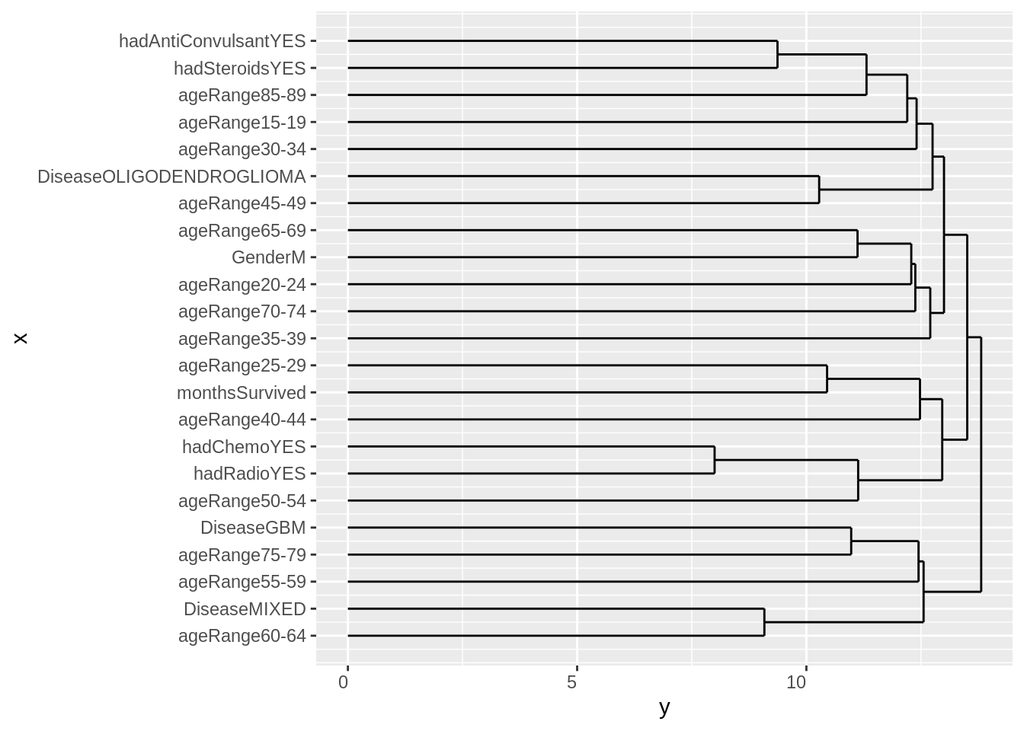

```r
hh = hclust(dist(t(scale(df3))))
ggdendrogram(hh, rotate = TRUE, theme_dendro = FALSE)
```

One observation we can make from the clustering is that patients that had steroid treatment to reduce inflamation also probably had anti-convulsant medication.

We can perform ANOVA:

Assumptions: normally distributed, iid Looking at the residual and qq plot they are approximately satisfied

```r
library(ggfortify)
df.aov <- df.pca
result.aov <- aov(monthsSurvived ~ Disease * hadChemo, data = df.aov)
summary(result.aov)
```

```
##                  Df Sum Sq Mean Sq F value Pr(>F)
## Disease           3  15918    5306   3.821 0.0136 *
## hadChemo          1    353     353   0.254 0.6158
## Disease:hadChemo  2   5004    2502   1.802 0.1727
## Residuals        69  95816    1389
## ---
## Signif. codes:  0 '***' 0.001 '**' 0.01 '*' 0.05 '.' 0.1 ' ' 1
```

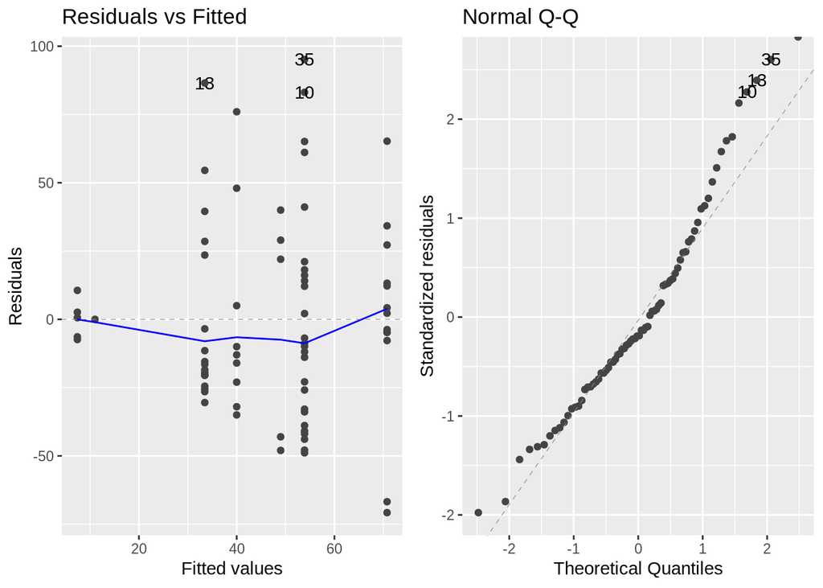

```r
autoplot(result.aov, which = 1:2)
```

We can conclude the type of disease has a significant effect on monthsSurvived

The residuals plot indicidates we dont have equal variance and the normal line is a bit wonky but I’m going to say they’re approximately satified assumptions.

```r
#devtools::install_github('topepo/caret/pkg/caret')
library(leaps)
df.glm <- df.pca

fit1 = lm(monthsSurvived ~ ., df.glm)
fit2 = lm(monthsSurvived ~ 1, df.glm)

fit3= step(lm(monthsSurvived ~ 1, df.glm), direction = "forward", scope = list(lower = fit2, upper = fit1))
```

```
## Start:  AIC=559.84
## monthsSurvived ~ 1
##
##                     Df Sum of Sq    RSS    AIC
## + ageRange          14     43219  73873 552.83
## + Disease            3     15918 101174 554.73
## + hadAntiConvulsant  1      7451 109641 556.84
## <none>                           117092 559.84
## + hadChemo           1      1050 116042 561.15
## + hadSteroids        1       421 116671 561.56
## + hadRadio           1       189 116903 561.72
## + Gender             1        38 117054 561.81
##
## Step:  AIC=552.83
## monthsSurvived ~ ageRange
##
##                     Df Sum of Sq   RSS    AIC
## + hadChemo           1    5490.8 68382 548.96
## <none>                           73873 552.83
## + hadAntiConvulsant  1    1503.2 72370 553.27
## + hadSteroids        1     668.0 73205 554.14
## + hadRadio           1     431.5 73441 554.39
## + Gender             1       0.9 73872 554.83
## + Disease            3    3772.3 70101 554.85
##
## Step:  AIC=548.96
## monthsSurvived ~ ageRange + hadChemo
##
##                     Df Sum of Sq   RSS    AIC
## <none>                           68382 548.96
## + hadAntiConvulsant  1   1310.79 67071 549.49
## + hadRadio           1    621.98 67760 550.27
## + hadSteroids        1    443.52 67939 550.47
## + Gender             1      0.01 68382 550.96
## + Disease            3   2445.99 65936 552.19
```

```r
fit4= step(lm(monthsSurvived ~ ., df.glm), direction = "backward", scope = list(lower = fit2, upper = fit1))
```

```
## Start:  AIC=556.3
## monthsSurvived ~ Gender + ageRange + Disease + hadSteroids +
##     hadAntiConvulsant + hadRadio + hadChemo
##
##                     Df Sum of Sq   RSS    AIC
## - Disease            3    2335.2 64975 553.08
## - Gender             1      22.1 62662 554.32
## - hadRadio           1     451.1 63091 554.84
## - hadSteroids        1    1053.3 63693 555.56
## <none>                           62640 556.30
## - hadAntiConvulsant  1    2383.3 65023 557.13
## - ageRange          14   29493.9 92134 557.62
## - hadChemo           1    3832.4 66472 558.81
##
## Step:  AIC=553.08
## monthsSurvived ~ Gender + ageRange + hadSteroids + hadAntiConvulsant +
##     hadRadio + hadChemo
##
##                     Df Sum of Sq    RSS    AIC
## - Gender             1        58  65033 551.15
## - hadRadio           1       638  65614 551.82
## - hadSteroids        1      1304  66279 552.59
## <none>                            64975 553.08
## - hadAntiConvulsant  1      2410  67385 553.85
## - hadChemo           1      5100  70075 556.82
## - ageRange          14     40279 105254 561.74
##
## Step:  AIC=551.15
## monthsSurvived ~ ageRange + hadSteroids + hadAntiConvulsant +
##     hadRadio + hadChemo
##
##                     Df Sum of Sq    RSS    AIC
## - hadRadio           1       594  65627 549.84
## - hadSteroids        1      1327  66361 550.68
## <none>                            65033 551.15
## - hadAntiConvulsant  1      2356  67389 551.85
## - hadChemo           1      5046  70079 554.83
## - ageRange          14     40493 105526 559.93
##
## Step:  AIC=549.84
```

[output cut: 11 more lines]

```
## monthsSurvived ~ ageRange + hadAntiConvulsant + hadChemo
##
##                     Df Sum of Sq    RSS    AIC
## - hadAntiConvulsant  1      1311  68382 548.96
## <none>                            67071 549.49
## - hadChemo           1      5298  72370 553.27
## - ageRange          14     41553 108624 558.13
##
## Step:  AIC=548.96
## monthsSurvived ~ ageRange + hadChemo
##
##            Df Sum of Sq    RSS    AIC
## <none>                   68382 548.96
## - hadChemo  1      5491  73873 552.83
## - ageRange 14     47660 116042 561.15
```

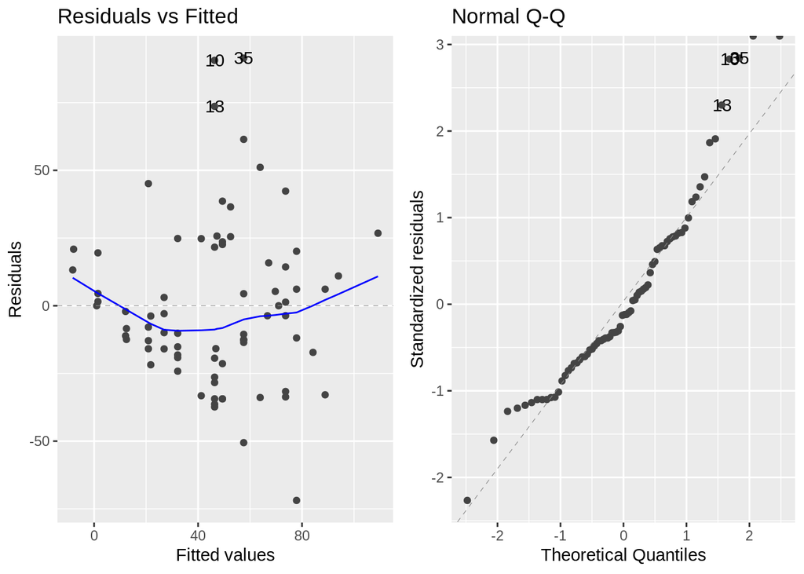

```r
autoplot(fit4, which = 1:2)
```

```r
summary(fit3)
```

```
##
## Call:
## lm(formula = monthsSurvived ~ ageRange + hadChemo, data = df.glm)
##
## Residuals:
##    Min     1Q Median     3Q    Max
## -71.89 -18.42  -3.75  19.68  91.44
##
## Coefficients:
##               Estimate Std. Error t value Pr(>|t|)
## (Intercept)     71.000     33.759   2.103   0.0397 *
## ageRange15-19   -3.833     41.605  -0.092   0.9269
## ageRange20-24   13.222     39.468   0.335   0.7388
## ageRange25-29   38.222     39.468   0.968   0.3367
## ageRange30-34   23.000     36.954   0.622   0.5360
## ageRange35-39    6.889     35.677   0.193   0.8475
## ageRange40-44   -1.286     36.954  -0.035   0.9724
## ageRange45-49  -18.500     36.475  -0.507   0.6139
## ageRange50-54   -4.300     36.376  -0.118   0.9063
## ageRange55-59  -29.778     36.984  -0.805   0.4239
## ageRange60-64  -23.734     37.717  -0.629   0.5316
## ageRange65-69  -58.556     39.104  -1.497   0.1395
## ageRange70-74  -49.200     37.397  -1.316   0.1933
## ageRange75-79  -58.889     39.104  -1.506   0.1373
## ageRange85-89  -70.000     47.743  -1.466   0.1478
## hadChemoYES    -20.333      9.264  -2.195   0.0320 *
## ---
## Signif. codes:  0 '***' 0.001 '**' 0.01 '*' 0.05 '.' 0.1 ' ' 1
##
## Residual standard error: 33.76 on 60 degrees of freedom
## Multiple R-squared:  0.416,  Adjusted R-squared:   0.27
## F-statistic: 2.849 on 15 and 60 DF,  p-value: 0.002061
```

```r
summary(fit4)
```

```
##
## Call:
## lm(formula = monthsSurvived ~ ageRange + hadChemo, data = df.glm)
##
## Residuals:
##    Min     1Q Median     3Q    Max
## -71.89 -18.42  -3.75  19.68  91.44
##
## Coefficients:
##               Estimate Std. Error t value Pr(>|t|)
## (Intercept)     71.000     33.759   2.103   0.0397 *
## ageRange15-19   -3.833     41.605  -0.092   0.9269
## ageRange20-24   13.222     39.468   0.335   0.7388
## ageRange25-29   38.222     39.468   0.968   0.3367
## ageRange30-34   23.000     36.954   0.622   0.5360
## ageRange35-39    6.889     35.677   0.193   0.8475
## ageRange40-44   -1.286     36.954  -0.035   0.9724
## ageRange45-49  -18.500     36.475  -0.507   0.6139
## ageRange50-54   -4.300     36.376  -0.118   0.9063
## ageRange55-59  -29.778     36.984  -0.805   0.4239
## ageRange60-64  -23.734     37.717  -0.629   0.5316
## ageRange65-69  -58.556     39.104  -1.497   0.1395
## ageRange70-74  -49.200     37.397  -1.316   0.1933
## ageRange75-79  -58.889     39.104  -1.506   0.1373
## ageRange85-89  -70.000     47.743  -1.466   0.1478
## hadChemoYES    -20.333      9.264  -2.195   0.0320 *
## ---
## Signif. codes:  0 '***' 0.001 '**' 0.01 '*' 0.05 '.' 0.1 ' ' 1
##
## Residual standard error: 33.76 on 60 degrees of freedom
## Multiple R-squared:  0.416,  Adjusted R-squared:   0.27
## F-statistic: 2.849 on 15 and 60 DF,  p-value: 0.002061
```

Both methods determined that age and whether a patient had chemo were the best predictors of monthsSurvived.